# Übungsaufgabe 02: Pascalsches Dreieck

Implementiere eine **rekursive Funktion**, die das Pascalsche Dreieck zurückliefert.

```
        1
      1   1
    1   2   1
  1   3   3   1
1   4   6   4   1
```

Das Pascalsche Dreieck ist eine Form der grafischen Darstellung der Binomialkoeffizienten, die auch eine einfache Berechnung dieser erlaubt. Sie sind im Dreieck derart angeordnet, dass jeder Eintrag die Summe der zwei darüberstehenden Einträge ist.

Mehr Information unter https://de.wikipedia.org/wiki/Pascalsches_Dreieck

Die Funktion soll das Dreieck in Form einer **zweidimensionalen Liste** zurückgeben. Als Parameter wird die Anzahl der gewünschten Zeilen übergeben.

Ergebnis für die ersten drei Zeilen des Dreiecks: `[[1], [1, 1], [1, 2, 1]]`

Folgendes Code-Stub kann als Ausgangsbasis verwendet werden:

```python
def pascalsTriangle(n):
    pass

for line in pascalsTriangle(6):
    print(line)
```

[output not shown]

Implementiere eine Funktion zur Berechnung der Fibonacci-Zahlen aus dem Pascalschen Dreieck.

Die Fibonacci-Zahlen können aus dem Pascalschen Dreieck abgeleitet werden, indem die farbigen **"flachen" Diagonalen** aufsummiert werden.

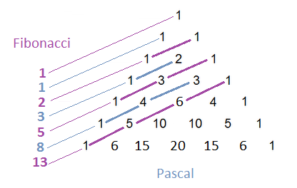

Die Funktion soll die Fibonacci-Zahlen in Form einer Liste zurückgeben. Als Parameter wird die Anzahl der gewünschten Fibonacci-Zahlen übergeben.

Ergebnis für die ersten 8 Fibonacci-Zahlen: `[0, 1, 1, 2, 3, 5, 8, 13]`

Folgendes Code-Stub kann als Ausgangsbasis verwendet werden:

```python
def fibonacciPascalsTriangle(n):
    pass

print(fibonacciPascalsTriangle(8))
```

[output not shown]

### Abgabe

Im [TeachCenter](https://tc.tugraz.at/main/course/view.php?id=938) bis zur nächsten Einheit.

Lade ein Archiv `ex02PascalsTriangle.zip` mit allen Dateien vor der nächsten Vorlesung (13:00 Uhr) im Abgabebereich der entsprechenden Aufgabe hoch.